# Overlapping hits between superintronic, index, ISA and IRfinder

Stuart Lee

2020-04-07

# 1 Introduction

Here we look at the overlap between the following methods:

- superintronic run on all kits in each of the HCC827 and NCIH1975 celllines

```r
# only polyA results
polyA_sets <- hits %>%
  filter(Kit == "polyA") %>%
  distinct(gene_id) %>%
  arrange(gene_id) %>%
  mutate(value = 1,
         var = paste0("superintronic:", gsub("-", "", CellLine),"_", Kit)) %>%
  ungroup() %>%
  plyranges::select(gene_id, var, value) %>%
  tidyr::spread(var, value) %>%
  dplyr::mutate_at(2:3, .funs = ~ dplyr::if_else(is.na(.), 0L, 1L)) %>%
  left_join(parts_tbl)
totalRNA_sets <- hits %>%
  filter(Kit == "total-RNA") %>%
  distinct(gene_id) %>%
  arrange(gene_id) %>%
  mutate(value = 1,
         var = paste0("superintronic:", gsub("-", "", CellLine),"_", Kit)) %>%
  ungroup() %>%
  plyranges::select(gene_id, var, value) %>%
  tidyr::spread(var, value) %>%
  dplyr::mutate_at(2:3, .funs = ~ dplyr::if_else(is.na(.), 0L, 1L)) %>%
  left_join(parts_tbl)
totalRNA_sets
```

```
## # A tibble: 60 x 4
##    gene_id        `superintronic:HCC287_to… `superintronic:NCIH1975_t… gene_name
##    <chr>                              <int>                      <int> <chr>
##  1 ENSG000000058…                         1                          1 ITGA3
##  2 ENSG000000383…                         1                          1 TRIO
##  3 ENSG000000504…                         0                          1 LETMD1
##  4 ENSG000000559…                         1                          0 PUM2
##  5 ENSG000000672…                         1                          1 PKM
##  6 ENSG000000716…                         0                          1 DAZAP1
##  7 ENSG000000963…                         1                          1 HSP90AB1
##  8 ENSG000001008…                         0                          1 DHRS2
##  9 ENSG000001012…                         0                          1 CDC25B
## 10 ENSG000001021…                         1                          0 PGK1
## # … with 50 more rows
```

- IRfinder using
  - the Audic and Claverie test

```r
irf_ac <- ir_finder_ac %>%
  left_join(parts_tbl, by = "gene_name") %>%
  select(gene_id = gene_id.y, gene_name, adj_pval = p_diff) %>%
  mutate(`IRFinder_AC` = 1L)
```

- GLM test (one gene is dropped as it’s no longer present in hg38 annotation)

```r
irf_glm <- ir_finder_glm %>%
  group_by(gene_name, gene_id) %>%
  tidyr::nest() %>%
  left_join(parts_tbl, by = "gene_name") %>%
  left_join(parts_tbl %>%
              mutate(gene_id2 = stringr::str_replace(gene_id, "\\.[1-9]{1,}", "")),
            by = c("gene_id.x" = "gene_id2")) %>%
  group_by(gene_name.x) %>%
  mutate(canon_gene_id = list(unique(c(gene_id, gene_id.y))),
         canon_gene_id = lapply(canon_gene_id, function(x) {
           if (any(!is.na(x))) return(x[!is.na(x)])
           return(NA_character_)
         }),
         canon_gene_id = as.character(unlist(canon_gene_id))) %>%
  ungroup() %>%
  select(gene_name = gene_name.y, gene_id = canon_gene_id, data) %>%
  filter(!is.na(gene_id)) %>%
  mutate(`IRFinder_GLM` = 1L)

irf_glm
```

```
## # A tibble: 303 x 4
##    gene_name              gene_id            data              IRFinder_GLM
##    <chr>                  <chr>              <list>                   <int>
##  1 ACADVL                 ENSG00000072778.19 <tibble [12 × 2]>            1
##  2 AC008982.1             ENSG00000268083.5  <tibble [7 × 2]>             1
##  3 CDKN2A                 ENSG00000147889.17 <tibble [1 × 2]>             1
##  4 HNRNPL                 ENSG00000104824.16 <tibble [2 × 2]>             1
##  5 CPNE1                  ENSG00000214078.12 <tibble [3 × 2]>             1
##  6 NOP56                  ENSG00000101361.16 <tibble [3 × 2]>             1
##  7 VCL                    ENSG00000035403.17 <tibble [2 × 2]>             1
##  8 STAG3L5P-PVRIG2P-PILRB ENSG00000272752.6  <tibble [1 × 2]>             1
##  9 CD44                   ENSG00000026508.17 <tibble [5 × 2]>             1
## 10 GLIPR1                 ENSG00000139278.9  <tibble [2 × 2]>             1
## # … with 293 more rows
```

- IsoformSwitchAnalyzeR using the DEXSeq test

```r
isa_sets <- isa_hits %>%
  mutate(`IsoformSwitchAnalyzeR` = 1L) %>%
  select(gene_id,
         `IsoformSwitchAnalyzeR`,
         gene_name,
         gene_switch_q_value,
         rank = Rank)

isa_sets
```

```
## # A tibble: 257 x 5
##    gene_id            IsoformSwitchAnalyzeR gene_name gene_switch_q_value  rank
##    <chr>                              <int> <chr>                   <dbl> <int>
##  1 ENSG00000234745.10                     1 HLA-B               0.            1
##  2 ENSG00000104823.8                      1 ECH1                5.95e-210     2
##  3 ENSG00000115641.18                     1 FHL2                3.63e-149     3
##  4 ENSG00000206503.12                     1 HLA-A               6.83e-141     4
##  5 ENSG00000170291.14                     1 ELP5                1.40e-120     5
##  6 ENSG00000008513.14                     1 ST3GAL1             2.18e- 59     6
##  7 ENSG00000155324.9                      1 GRAMD2B             9.48e- 57     7
##  8 ENSG00000114268.11                     1 PFKFB4              2.79e- 54     8
##  9 ENSG00000268043.7                      1 NBPF12              1.47e- 52     9
## 10 ENSG00000145736.14                     1 GTF2H2              1.14e- 39    10
## # … with 247 more rows
```

- index results

```r
library(index)
exon <- readRDS(system.file("extdata/exon_dge.Rds", package = "index"))
intron <- readRDS(system.file("extdata/intron_dge.Rds", package = "index"))
group <- readRDS(system.file("extdata/group.Rds", package = "index"))

x <- index_analysis(exon, intron, group, p.value = 0.01)
```

```
## creating design matrix by 'model.matrix(~group)'
```

```r
index_res <- x$tops$intron %>%
  filter(adj.P.Val < 0.01) %>%
  select(gene_id = GeneID, index_pval = adj.P.Val, logfc = logFC) %>%
  mutate(`index` = 1L) %>%
  as_tibble()

index_res
```

```
## # A tibble: 5,930 x 4
##    gene_id            index_pval  logfc index
##    <fct>                   <dbl>  <dbl> <int>
##  1 ENSG00000000003.14  0.00372   -0.995     1
##  2 ENSG00000000457.13  0.00132   -0.487     1
##  3 ENSG00000000460.16  0.000342  -0.804     1
##  4 ENSG00000000971.15  0.0000389 -1.31      1
##  5 ENSG00000001084.10  0.00161   -0.579     1
##  6 ENSG00000001461.16  0.0000205 -1.29      1
##  7 ENSG00000001497.16  0.000567  -0.726     1
##  8 ENSG00000001561.6   0.000316  -2.32      1
##  9 ENSG00000001617.11  0.0000168  4.80      1
## 10 ENSG00000001631.15  0.000621   0.484     1
## # … with 5,920 more rows
```

Note that these comparisons are not quite fair since the gene sets selected by each method after filtering are slighty different. Nonetheless we can visualise the overlap using an UpSet plot.

# 2 index sets overlapping total RNA comparisons

All hits discovered by superintronic except for 19 genes are obtained by the index analysis.

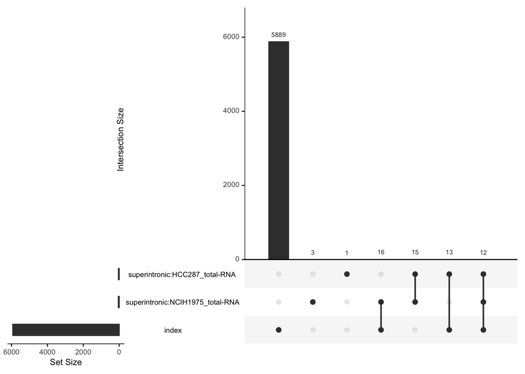

```r
library(UpSetR)
dex_set <- index_res %>%
  full_join(totalRNA_sets) %>%
  mutate_at(vars(index, starts_with("superintronic")),
            .funs = ~ if_else(is.na(.), 0L, .))
upset(as.data.frame(dex_set))
```

How many genes in DEList overlap with HCC287 total RNA = 13 How many genes in DEList overlap with NCIH1975 total RNA = 16 How many genes overlap between the overlapping genes = 12.

# 3 Compare IRfinder and ISA

superintronic detects genes with IR (IR-like profiles). If a gene is detected in Group A and not B, we can loosely say that it has differential IR (DIR) in Group A and B. Similarly for Group B.

Technically, a gene can be detected with IR in both Group A and B, but at different evels thus DIR – these genes are commonly detected in Group A and B, and are DE (see above).

```r
ir_sets <- isa_sets %>%
  full_join(polyA_sets) %>%
  full_join(irf_ac) %>%
  full_join(irf_glm) %>%
  mutate_at(vars(
                 starts_with("Isoform"),
                 starts_with("superintronic"),
                 starts_with("IRFinder")),
            .funs = ~ if_else(is.na(.), 0L, .))
```

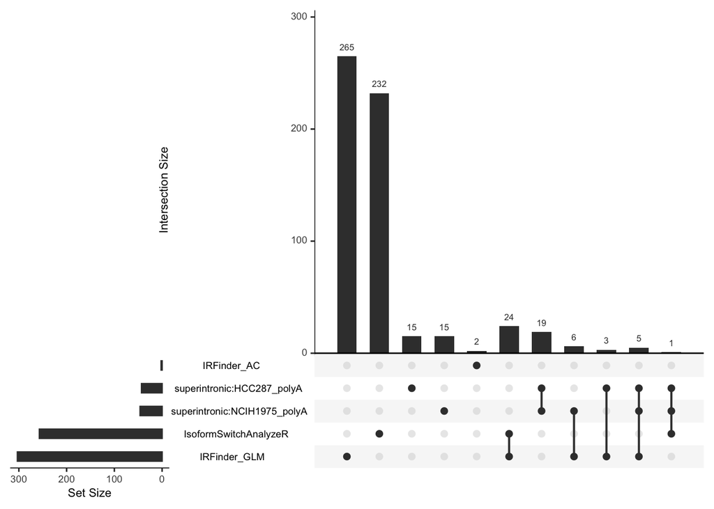

```r
plot_sets <- ir_sets %>%
  select(gene_id,
         starts_with("Isoform"),
         starts_with("superintronic"),
         starts_with("IRFinder"))
upset(as.data.frame(plot_sets))
```

How many unique genes to HCC287 poly(A) overlap with IRFinder?

0 from AC test; 8 from GLM test

How many unique genes to NCIH1975 poly(A) overlap with IRFinder?

0 from AC test; 11 from GLM test

Are there any common genes to both polyA celllines, that are also DE in intron counts (any category), that overlap with IRFinder? Yes, see below, there are three genes.

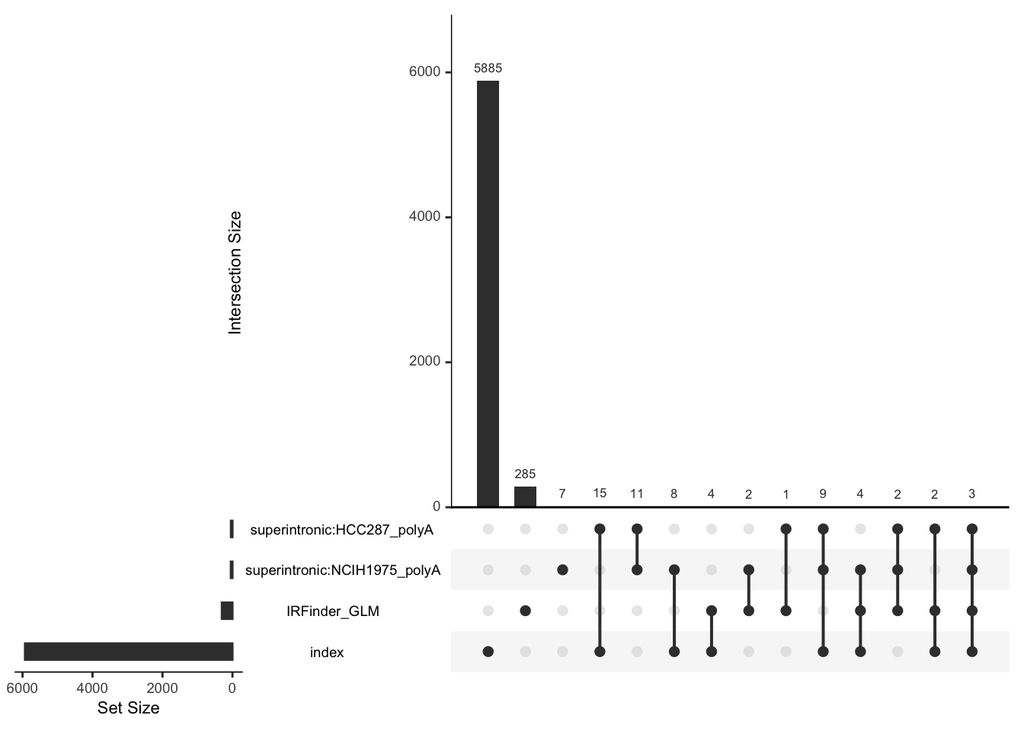

```r
de_sets <- index_res %>%
  full_join(polyA_sets) %>%
  full_join(irf_glm) %>%
  mutate_at(vars(index,
                 starts_with("superintronic"),
                 starts_with("IRFinder")),
            .funs = ~ if_else(is.na(.), 0L, .))
de_sets %>%
  select(gene_id, index, starts_with("superintronic"), starts_with("IRFinder")) %>%
  as.data.frame() %>%
  upset()
```

Are there any common genes to both poly(A) celllines, that are also DE in intron counts (any category), that overlap with ISA? No.

# 4 Comparing libraries

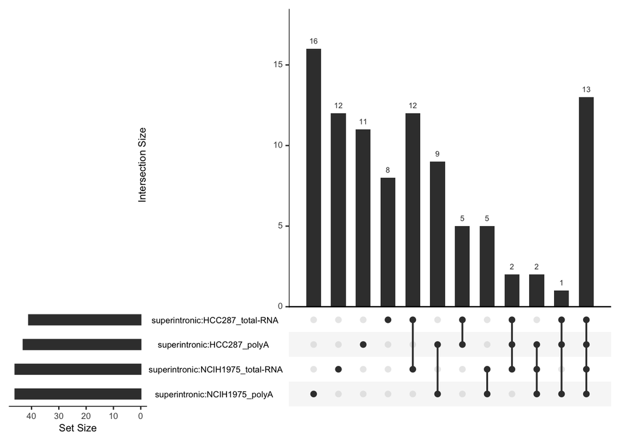

```r
libraries <- totalRNA_sets %>%
  full_join(polyA_sets) %>%
    mutate_at(vars(starts_with("superintronic")),
            .funs = ~ if_else(is.na(.), 0L, .))
libraries %>%
  select(gene_id, starts_with("superintronic")) %>%
  as.data.frame() %>%
  upset()
```